# IST772– Problem Set 10

# Chapter 11, Exercise 8

*Use bcp() on the AirPassengers time series. (1 pt) Plot and interpret the results. Make sure to contrast these results with those from Exercise 6. (1 pt)*

# 5) Question 8: Bayesian analysis | Change point analysis

- Changt point Analysis - Bayesian version
  - Bayesian version uses Markov chain Monte Carlo technique to develop a list of posterior priorities for mean changes at each point in the time series data.
  - bcp(as.vector(AirPassengers)) - this procedure expects the time series values as vector
  - plot(bAPcpm) - produces much richer output in time plot and gives much clearer view of what is happening in our time-series data.
- Results
  - Output of the bcp() procedure two sections
    - Posterior Probability
      - Lower pane shows the probablities of a mean change at each point in time
      - You may see that there are isoloated spikes closer to probability 1.Further this can be analyzed through plot(bAPcpm$posterior.prob >.95,col=“blue”)
        - this plot generates the plot with probability value less than or equal to 0.95 recorded as FALSE (i.e 0)
        - this plot generates the plot with probability value above to 0.95 recorded as TRUE (i.e 1)
    - Posterior Means
      - Upper pane shows the original time series.

```r
EnsurePackage("bcp")
```

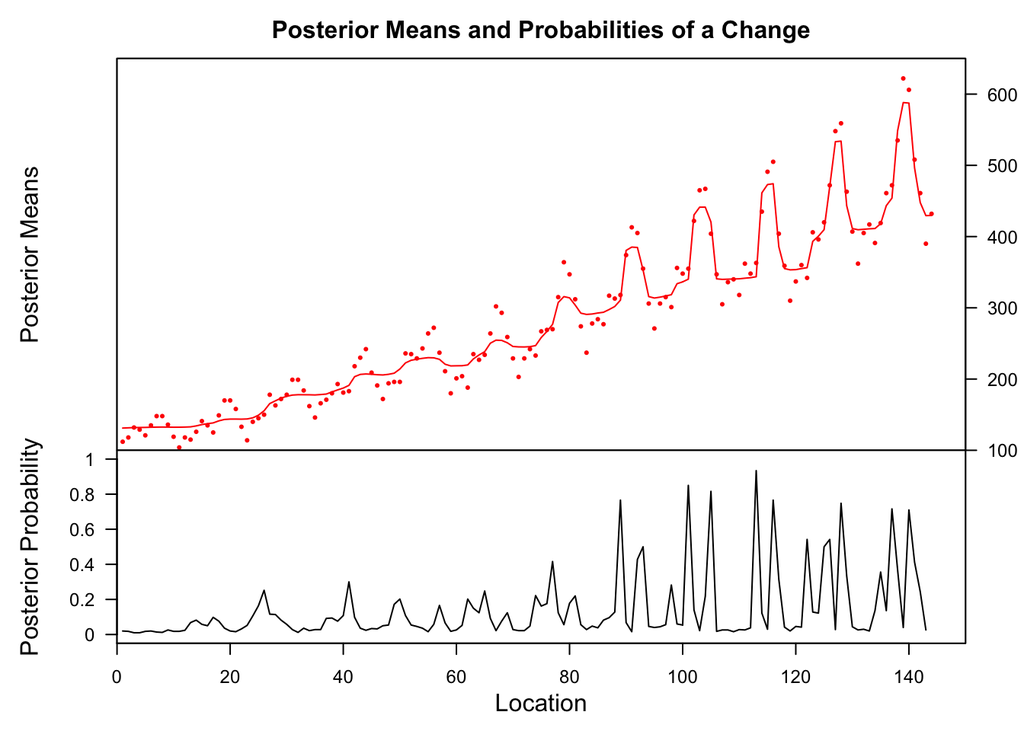

```r
# Bayesian Change point analysis
bAPcpm <- bcp(as.vector(AirPassengers))
plot(bAPcpm)
```

```r
# summary(bAPcpm)
```

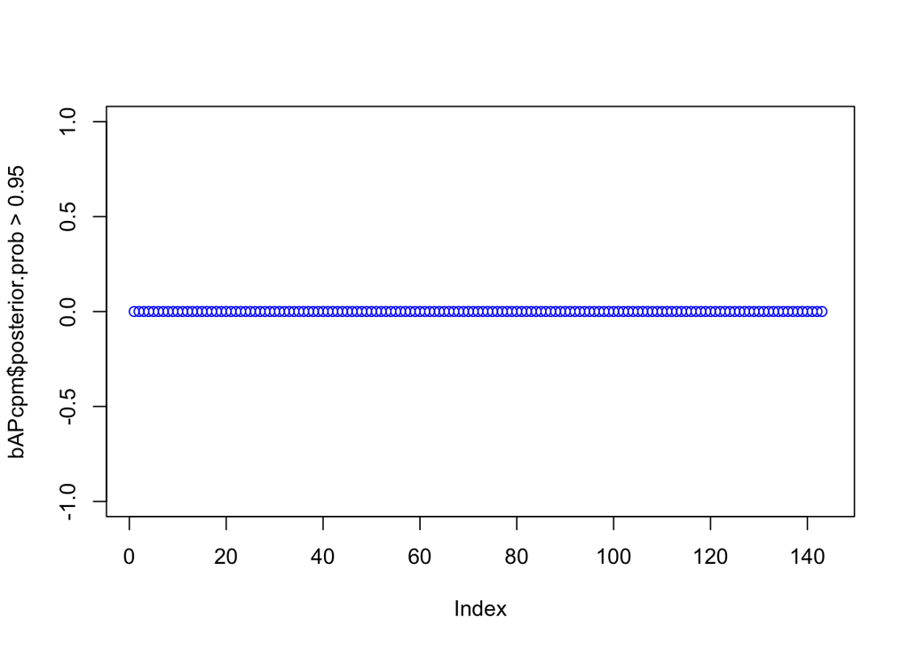

```r
plot(bAPcpm$posterior.prob >.95,col="blue")
```